# Social Power NBA Dataset

Julia Wilkins & Adrian Naranjo

## Data

- Found on Kaggle: https://www.kaggle.com/noahgift/social-power-nba
- Contains performance, salary, Wikipedia pageviews, and Twitter RT/Favorite data for players in the 2016-2017 season across 30 teams
- Performance statistics: $n = 446, p = 36$
- Social media statsitcs: $n = 239, p = 3$

## We asked, can we predict…

1. Salary from performance statistics?
2. Points per game based on other performance metrics?
3. Salary based on social media stats?

## Salary EDA: Distribution of Individual Salaries

### Right Skewed: Keep this in mind. We’ll cut the tail later.

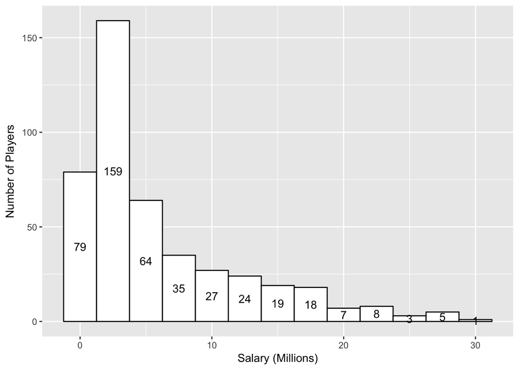

#### Note: bins are $2.5 mil

| Percentile | Salary |
| --- | --- |
| 0% | 31969 |
| 10% | 874636 |
| 20% | 1312611 |
| 30% | 1536288 |
| 40% | 2318280 |
| 50% | 3488000 |
| 60% | 5000000 |
| 70% | 7000000 |
| 80% | 11020000 |
| 90% | 15902211 |
| 100% | 30963450 |

## Salary by Position

### If you’re going to play, try playing center. Otherwise, nothing too interesting.

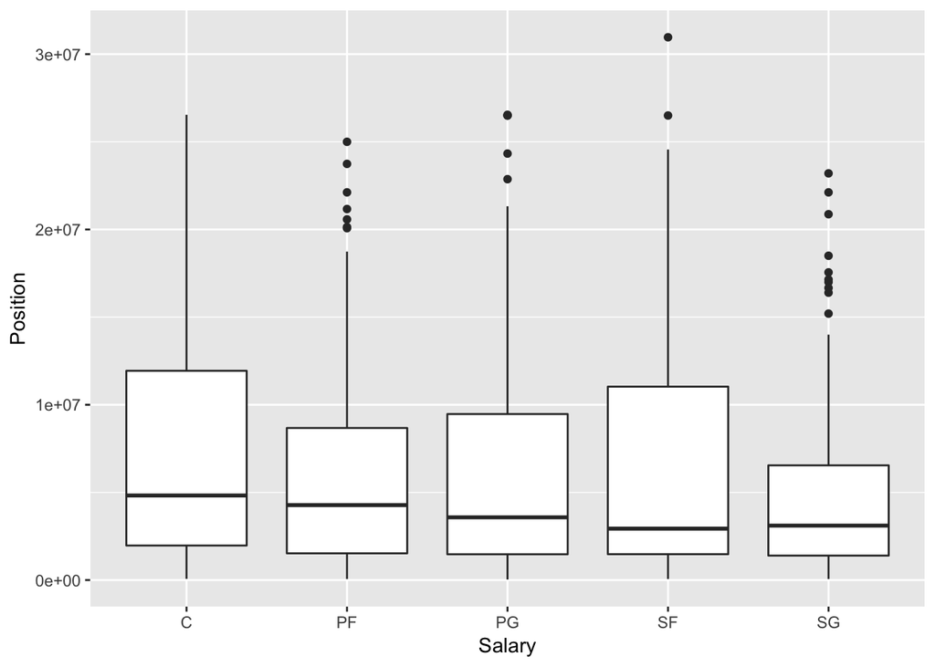

## Median Salary by Position

### In case you’re unsure center is the position for you (hint: it is)

| Position | Avg_Salary |
| --- | --- |
| C | 4.82 |
| PF | 4.28 |
| PG | 3.58 |
| SF | 2.93 |
| SG | 3.11 |

## Salary by Age

### Increases until leveling off and [slightly] declining. Makes sense: better players keep playing.

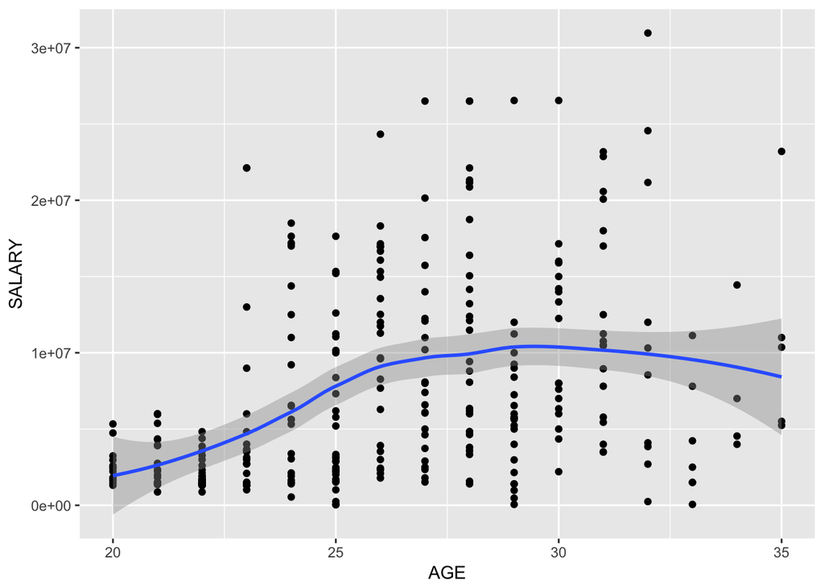

## Player Rating by Salary

### Obvious conclusion: the better you are, the better you get paid (generally!)

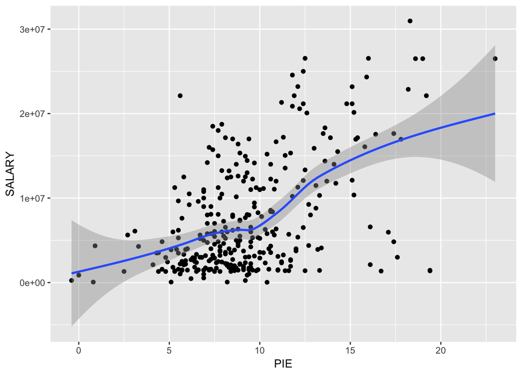

# Question 1: Can we predict **salary** from performance statistics?

## First, which predictors do we want?

```
##  [1] "X1"         "Rk"         "PLAYER"     "POSITION.x" "AGE"
##  [6] "MP"         "FG"         "FGA"        "FG%"        "3P"
## [11] "3PA"        "3P%"        "2P"         "2PA"        "2P%"
## [16] "eFG%"       "FT"         "FTA"        "FT%"        "ORB"
## [21] "DRB"        "TRB"        "AST"        "STL"        "BLK"
## [26] "TOV"        "PF"         "POINTS"     "TEAM.x"     "GP"
## [31] "MPG"        "ORPM"       "DRPM"       "RPM"        "WINS_RPM"
## [36] "PIE"        "PACE"       "W"          "SALARY"
```

## Including all predictors led to issues (hello, collinearity). So, we got rid of some (e.g. Offensive Rebounds) and kept others (e.g. Total Rebounds).

#### Note: to be precise: we eliminated 18 of the 40 variables

## But, we’d still prefer less variables: Best Subset Elimination

### No clear consensus.

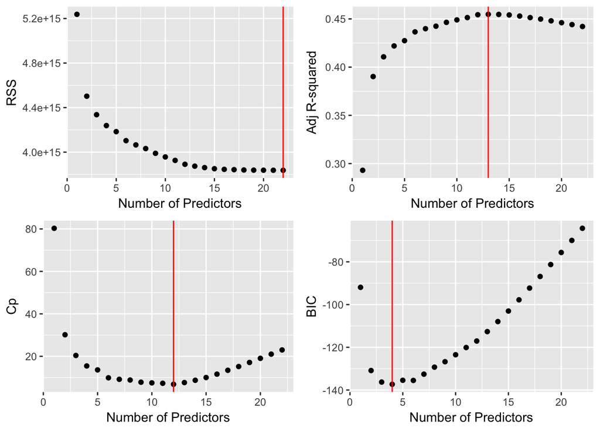

## Ok. Let’s build a bunch of models (Yay!)

| NumberOfPredictors | Predictors |
| --- | --- |
| 4 | Age, 2PA, MPG, W |
| 5 | Age, 2PA, MPG, W, 2P |
| 6 | Age, 2PA, W, 2P, ORB, POINTS |
| 7 | Age, 2PA, W, 2P, ORB, POINTS, TOV |
| 8 | Age, 2PA, W, 2P, ORB, POINTS, TOV, STL |
| 9 | Age, W, 2P, ORB, POINTS, TOV, MPG, 3PA, FGA |
| 10 | Age, W, 2P, ORB, POINTS, TOV, MPG, 3PA, FGA, 2PA |
| 5 (Gamma) | Age, 2PA, 2P, 2PA, ORB, MPG |

## Actual versus Predicted Plots

### Not much of a difference, at least visually

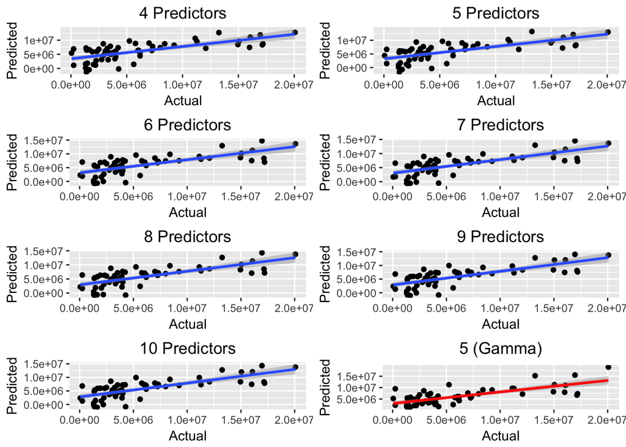

## Let’s be more exact: what’s the Test MSE

### Keep in mind, salaries are in the millions!

| Model4 | Model5 | Model6 | Model7 | Model8 | Model9 | Model10 | Gamma |
| --- | --- | --- | --- | --- | --- | --- | --- |
| 3758985 | 3714126 | 3635247 | 3584621 | 3564809 | 3522045 | 3486232 | 7915173 |

## How about K-Fold CV (using 5 folds)?

| Model4 | Model5 | Model6 | Model7 | Model8 | Model9 | Model10 | Gamma |
| --- | --- | --- | --- | --- | --- | --- | --- |
| 3836217 | 3827599 | 3814848 | 3811431 | 3805729 | 3814579 | 3808705 | 8001577 |

## Are we better suited with a non-linear model?

### Do any patterns appear while ploting prominent variables against salary

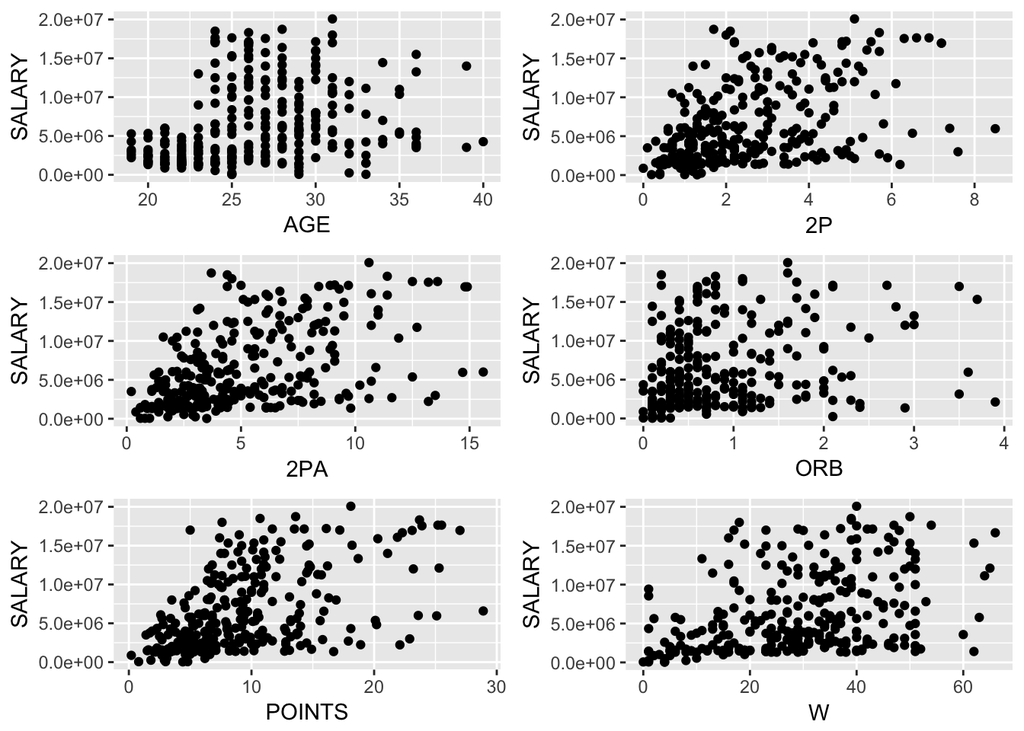

## Attempt at Non-Linear Models (Local Regression)

### Yeah…. No. Not conclusive.

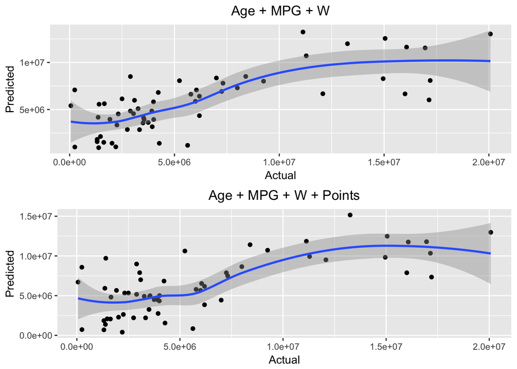

| NonLinear_3P | NonLinear_4P |
| --- | --- |
| 3514749 | 3643381 |

# Question 2: **Points per game** based on other performance metrics?

- Choose to use 4 predictors: 3P, FT, FG, 2P because of statistical significance
- Tried using regsubsets but there were a lot of problems with collinearities
- Still found number of predictors to be 3-4 (predictors above)
- “Points” is the player’s average number of PPG, whereas these statistics are **quantity** of those shots made
- Less 3’s made overall, still trending upward with point total however

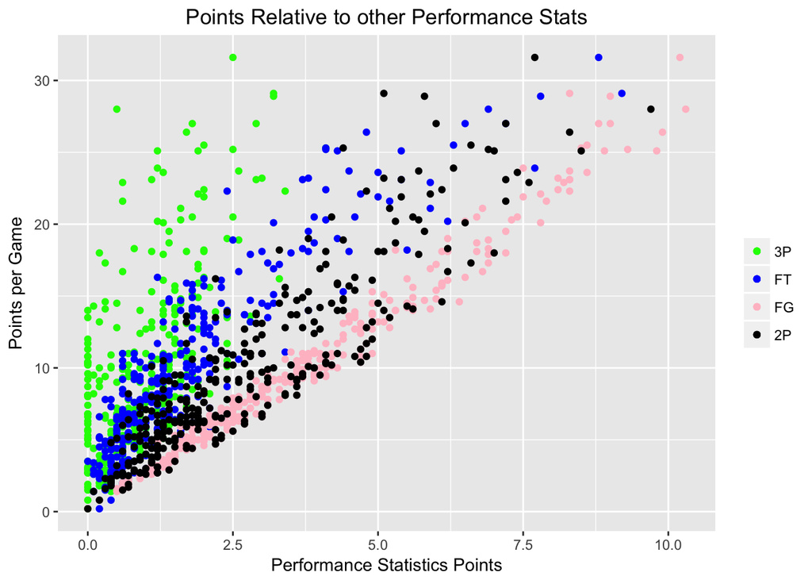

### Create a simple linear model

- Validation set approach with 0.75/0.25 train/test split
- Simple linear regression model with 4 predictors does very well
- Is this because the predictors are correlated **too well** with the response?

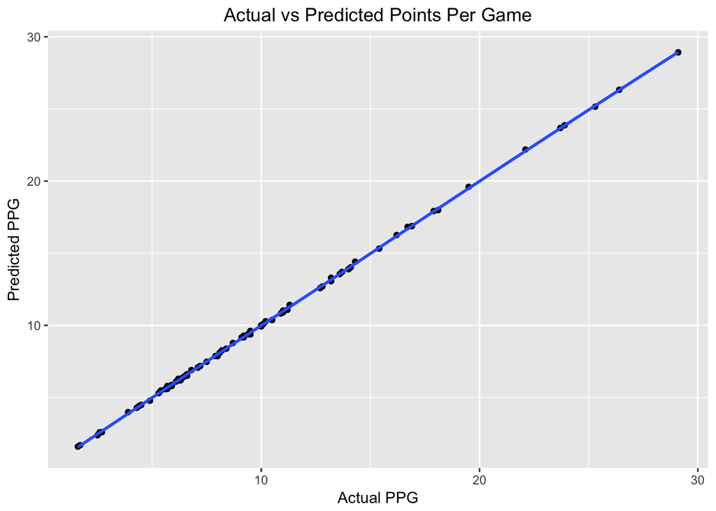

### Almost too perfect… RMSE of just 0.075. Let’s check to make sure that “Points” isn’t simply just the sum of our predictors (-FG) multiplied by their point values. It’s close, but not quite there. This is still unsettling, and probably not that useful.

| original_points | pred_points | sum_col |
| --- | --- | --- |
| 29.1 | 28.920 | 29.0 |
| 26.4 | 26.328 | 26.5 |
| 25.3 | 25.155 | 25.2 |
| 23.9 | 23.865 | 23.9 |
| 23.7 | 23.678 | 23.7 |
| 22.1 | 22.184 | 22.2 |
| 19.5 | 19.596 | 19.6 |
| 18.1 | 17.984 | 18.0 |
| 17.9 | 17.922 | 18.1 |
| 16.9 | 16.878 | 16.9 |

### For good measure, let’s check out predicting points based on field goals alone - the make-up of shots that a person can have to generate the same number of points can vary so let’s see if it learns this.

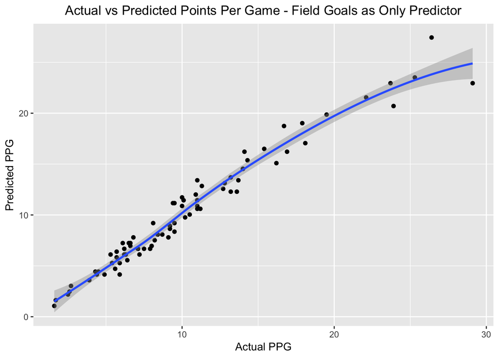

#### This feels a little better, and our test RMSE is now 1.15.

# Question 3: **Salary** based on social media stats?

### Weak positive correlation between salary and wikipedia pageviews with outliers

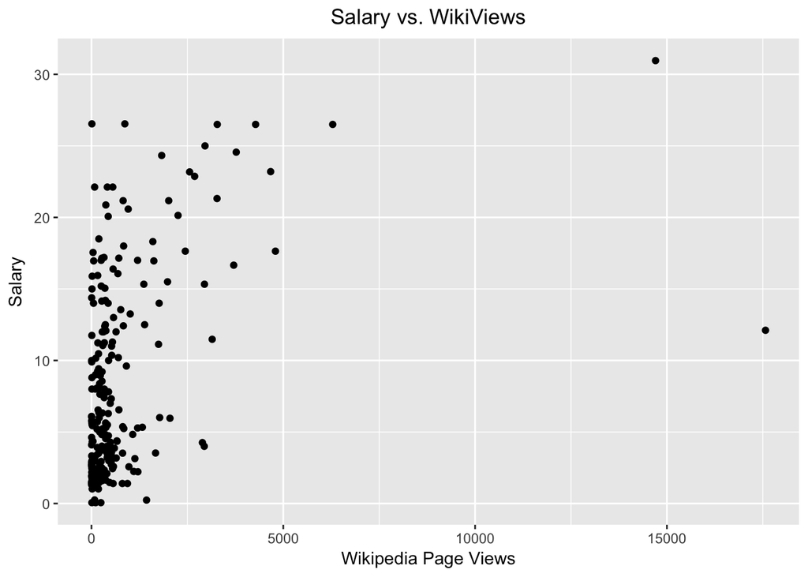

### Make simple linear model for predicting **salary** based on Wikipedia pageviews alone, combined Twitter statistics, and then all 3 predictors.

- Validation set approach with 0.75/0.25 train/test split

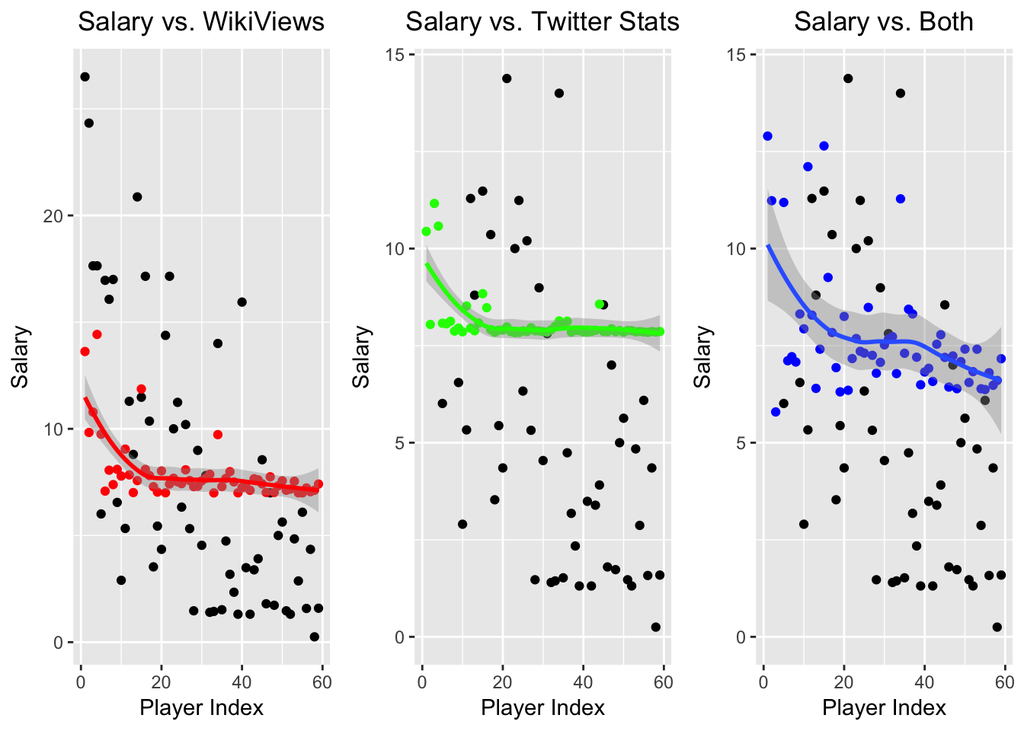

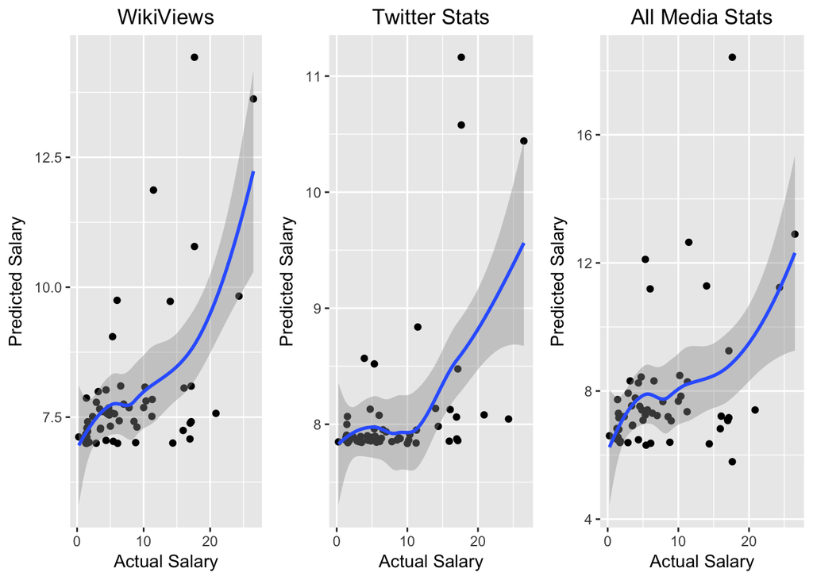

#### Compare Test RMSE of each model:

(Note: RMSE is scaled in millions (i.e. 6.7 million))

| wiki_rmse | twitter_rmse | media_rmse |
| --- | --- | --- |
| 5.71367 | 6.096012 | 5.800821 |

### These results are not great, and intuitively Wikipedia pageviews would be the only predictor we would expect to really correlate.